# Project 5

Callback Cats

2022-10-10

# Introduction

Thermoregulation is the ability of an organism to regulate their temperature within certain parameters. Internal thermoregulation is known as homeostasis which is a dynamic stability that plays an important role during physical exercise and periods of rest. The previous study, Lim, Byrne, and Lee (2008), discusses the complexity of thermoregulation in humans, and the regulation of body temperature during physical exertion. When human subjects increase their activity from sedentary to active, there is a decrease in skin temperature due to an increase in perspiration. production.

# Methods

An Arduino-based temperature recording system using the DHT11 sensor was implemented to record body temperatures of subjects over a 100 second period at two different intervals, once during the subject’s resting state and again after 5 minutes of activity (jumping jacks). The data captured for each subject was saved in a CSV file that was then loaded into R for analysis. Mean temperatures for each subject were plotted and combined into one figure for comparison of activity temperatures between subjects.

[figure not shown]

A jumping jack

### Loading the Data and Tidyverse

```r
library(tidyverse)
dat.f <- list.files(pattern = "couch|active.csv")    #find the files
```

### Combine the active and couch data into a list

```r
dat.l <- list()
#make an empty list

for(i in dat.f){
  met.dat<- unlist(strsplit(i,"_"))
  #split of the filename string
  who <- met.dat[1]
  #store the first element
  activity <- gsub(".csv","",met.dat[2])
  #store second element, dropping CSV with gsub()
  dat.l[[i]]<- read_csv(i)%>%
    mutate(who=who,activity=activity)
  #read, then store data with additional columns of metada in list as position unique to i
}

dat <- do.call(rbind,dat.l)
#combine the list into table
```

# Results

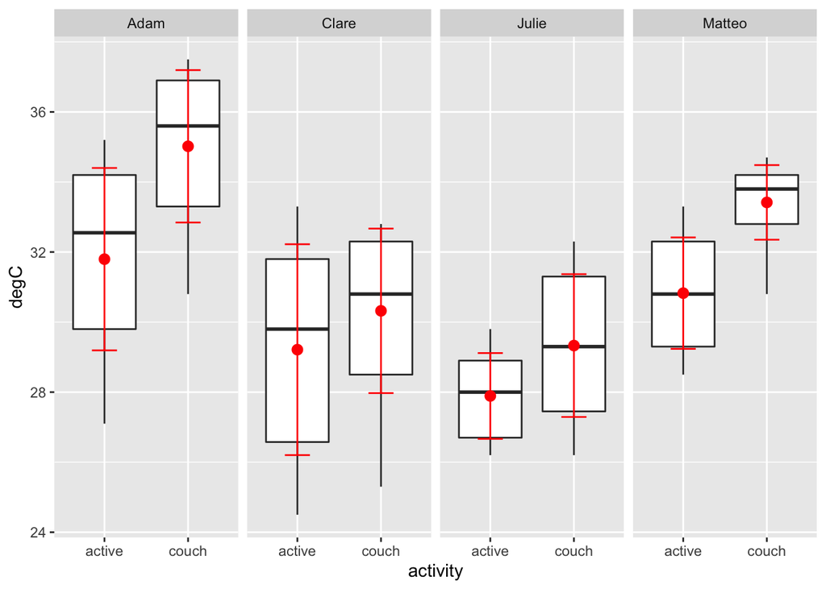

# Discussion

The objective of this report is to answer “Does body temperature vary in human subjects according to activity level?” Recordings from the Arduino DHT11 sensor showed the baseline of body temperature when in sedentary position. When group members engaged in physical activity, temperatures decreased. This was congruent with the findings from Lim, Byrne, and Lee (2008) that demonstrated how skin temperature varies with physical activity. When transitioning from sedentary to activity, there is an initial reduction in skin temperature as a result of evaporative cooling. As explained in the article, the decreasing temperature is a result of heat dissipating from the active muscles to the skin surface during exercise and it is also related to the redirection of blood flow to active muscles.

# Author Contributions

Data collection was worked on by all members of the team and all members also contributed to proofreading of data, results, and R code. Clare Mungovan: Worked on the Introduction section. Adam Qu: Described the methods used for this report. Matteo Torquati: Put in all the code into Rmd file and formatted it. Julie Vu: Worked on the discussion section.

# References

Lim, Chin Leong, Chris Byrne, and Jason KW Lee. 2008. “Human Thermoregulation and Measurement of Body Temperature in Exercise and Clinical Settings.” *Annals Academy of Medicine Singapore* 37 (4): 347.